# Illusion Game Reliability

Preprocessing

Dominique Makowski et al.

2022-11-22

# Preprocessing

```r
library(tidyverse)
library(ggdist)
library(ggside)
library(easystats)
library(patchwork)

illusion1 <- read.csv("../data/raw_illusion1.csv") |>
  mutate(
    Illusion_Effect = fct_relevel(as.factor(Illusion_Effect), "Incongruent", "Congruent"),
    Block = as.factor(Block)
  )

illusion2 <- read.csv("../data/raw_illusion2.csv") |>
  mutate(
    Illusion_Effect = fct_relevel(as.factor(Illusion_Effect), "Incongruent", "Congruent"),
    Block = as.factor(Block)
  )

perceptual <- read.csv("../data/raw_perceptual.csv") |>
  mutate(
    Block = as.factor(Block)
  )

sub <- read.csv("../data/raw_questionnaires.csv")

#   mutate(
#     Education = fct_relevel(Education, "High School", "Bachelor", "Master", "Doctorate", "Other", "Prefer not to Say")
#   )
```

# Outlier Detection (Tasks)

```r
# Dear participant, thank you for participating in our study. Unfortunately, our system detected multiple issues in your data (such as implausibly short responses - in particular in the 2nd part of the study, random-like pattern of answers, or the same response to different scales - as some were designed to trigger various answers), which makes it unusable. We understand that you might have been in a hurry or had some other issues, and so we kindly ask you to return your participation; we hope to open-up more slots in the future would you be interested to participate again.

# Dear participant, thank you for participating in our study. Unfortunately, our system detected multiple issues in your data (such as implausibly short responses - in particular in the 2nd part of the study, random-like pattern of answers, or the same response to different scales - as some were designed to trigger various answers), which makes it unusable for us. We understand that you might have been in a hurry or had some other issues; we hope to open-up more slots in the future would you be interested to participate again.

outliers_perceptual <- c(
  "S003",
  "S008"
)
outliers_illusion1 <- c(
  "S008"
  )
outliers_illusion2 <- c(
  "S003"
)
```

We removed 1, 2, and 1 participants for the illusion task - session 1, perceptual task, and illusion task - session 2 respectively, upon inspection of the average error rage (when close to 50%, suggesting random answers) and/or when the reaction time distribution was implausibly fast.

### Descriptive Table

```r
data <- rbind(illusion1, illusion2, perceptual) |>
  filter(RT < 10) |>
  mutate(
    Participant = fct_rev(Participant),
    Task = fct_relevel(Task, "Illusion_Session1", "Perceptual", "Illusion_Session2")
  )

table <- data |>
  group_by(Participant, Task) |>
  summarize(
    Error = sum(Error) / n(),
    RT = mean(RT)
  ) |>
  ungroup() |>
  arrange(desc(Error)) |>
  tidyr::pivot_wider(names_from = "Task", values_from = c("Error", "RT"), names_vary = "slowest") |>
  datawizard::data_relocate(ends_with("Session2"), after = -1) |>
  arrange(desc(Error_Illusion_Session1))
```

```r
data.frame(Participant = c("Average"), t(sapply(table[2:ncol(table)], mean, na.rm = TRUE))) |>
  rbind(table) |>
  knitr::kable() |>
  kableExtra::row_spec(1, italic = TRUE, background = "grey", color = "white") |>
  kableExtra::row_spec(which(table$Participant %in% c(outliers_perceptual, outliers_illusion1, outliers_illusion2)) + 1, background = "#EF9A9A") |>
  # kableExtra::column_spec(2, color="white",
  #                         background = kableExtra::spec_color(c(NA, table$Error_Illusion_Session1))) |>
  kableExtra::kable_styling(full_width = TRUE) |>
  kableExtra::scroll_box(width = "100%", height = "500px")
```

| Participant | Error_Perceptual | RT_Perceptual | Error_Illusion_Session1 | RT_Illusion_Session1 | RT_Illusion_Session2 | Error_Illusion_Session2 |
| --- | --- | --- | --- | --- | --- | --- |
| Average | 0.133 | 0.775 | 0.218 | 0.841 | 0.731 | 0.265 |
| S008 | 0.500 | 0.347 | 0.417 | 0.610 |  |  |
| S002 | 0.115 | 0.872 | 0.346 | 0.713 | 0.945 | 0.396 |
| S006 | 0.089 | 0.620 | 0.258 | 0.529 | 0.723 | 0.216 |
| S007 | 0.089 | 0.770 | 0.234 | 0.894 |  |  |
| S003 | 0.214 | 0.441 | 0.211 | 0.853 | 0.331 | 0.371 |
| S001 | 0.323 | 0.946 | 0.199 | 0.986 |  |  |
| S009 | 0.010 | 0.633 | 0.164 | 0.833 |  |  |
| S004 | 0.010 | 0.800 | 0.161 | 1.051 |  |  |
| S011 | 0.042 | 0.657 | 0.159 | 0.755 | 0.687 | 0.185 |
| S005 | 0.000 | 0.999 | 0.125 | 0.877 |  |  |
| S010 | 0.068 | 1.439 | 0.122 | 1.152 | 0.968 | 0.159 |

### Reaction Time Distribution

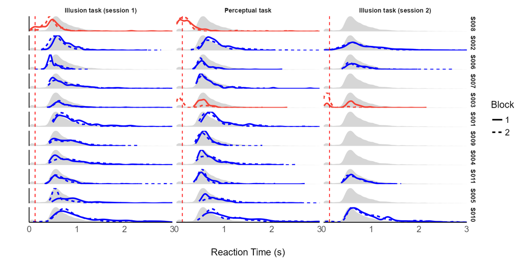

```r
p <- data |>
  estimate_density(select = "RT", at = c("Participant", "Task", "Block")) |>
  group_by(Participant) |>
  normalize(select = "y") |>
  ungroup() |>
  mutate(
    Participant = fct_relevel(Participant, as.character(table$Participant)),
    color = case_when(
      Participant %in% outliers_perceptual & Task == "Perceptual" ~ "red",
      Participant %in% outliers_illusion1 & Task == "Illusion_Session1" ~ "red",
      Participant %in% outliers_illusion2 & Task == "Illusion_Session2" ~ "red",
      TRUE ~ "blue"
    ),
    Task = fct_recode(Task,
      "Illusion task (session 1)" = "Illusion_Session1",
      "Illusion task (session 2)" = "Illusion_Session2",
      "Perceptual task" = "Perceptual"
    )
  ) |>
  ggplot(aes(x = x, y = y)) +
  geom_area(data = normalize(estimate_density(data, select = "RT"), select = "y"), alpha = 0.2) +
  geom_line(aes(color = color, group = interaction(Participant, Block), linetype = Block), size = 1) +
  geom_vline(xintercept = 0.125, linetype = "dashed", color = "red") +
  scale_color_manual(values = c("red" = "#F44336", "orange" = "#FF9800", "blue" = "blue"), guide = "none") +
  scale_x_continuous(expand = c(0, 0)) +
  scale_y_continuous(expand = c(0, 0)) +
  coord_cartesian(xlim = c(0, 3)) +
  theme_modern() +
  theme(axis.text.y = element_blank()) +
  facet_grid(Participant ~ Task) +
  labs(y = "", x = "Reaction Time (s)")
# p
ggsave("figures/outliers_RT.png", p, width = 10, height = 5, dpi = 150)
knitr::include_graphics("figures/outliers_RT.png")
```

```r
illusion1 <- filter(illusion1, !Participant %in% outliers_illusion1)
illusion2 <- filter(illusion2, !Participant %in% outliers_illusion2)
perceptual <- filter(perceptual, !Participant %in% outliers_perceptual)
```

# Outliers Detection (Blocks)

For each block, we computed the error rate and, if more than 50%, we discarded the whole block (as it likely indicates that instructions got mixed up, for instance participants were selecting the smaller instead of the bigger circle).

```r
data <- rbind(illusion1, illusion2, perceptual) |>
  group_by(Participant, Task, Illusion_Type, Block) |>
  summarize(ErrorRate_per_block = sum(Error) / n()) |>
  ungroup() |>
  arrange(desc(ErrorRate_per_block))


data |>
  estimate_density(at = c("Task", "Illusion_Type", "Block"), method = "KernSmooth") |>
  ggplot(aes(x = x, y = y)) +
  geom_line(aes(color = Illusion_Type, linetype = Block)) +
  geom_vline(xintercept = 0.5, linetype = "dashed") +
  scale_x_continuous(expand = c(0, 0)) +
  scale_y_continuous(expand = c(0, 0)) +
  scale_color_manual(values = c("Ebbinghaus" = "#2196F3", "MullerLyer" = "#4CAF50", "VerticalHorizontal" = "#FF5722")) +
  labs(y = "Distribution", x = "Error Rate") +
  theme_modern() +
  facet_wrap(~Task)
```

[figure not shown]

```r
remove_badblocks <- function(df) {
  n <- nrow(df)
  df <- df |>
    group_by(Participant, Illusion_Type, Block) |>
    mutate(ErrorRate_per_block = sum(Error) / n()) |>
    ungroup() |>
    filter(ErrorRate_per_block < 0.5) |>
    select(-ErrorRate_per_block)
  text <- paste0(
    "We removed ",
    n - nrow(df),
    " (",
    insight::format_value((n - nrow(df)) / n, as_percent = TRUE),
    ") trials belonging to bad blocks."
  )
  list(data = df, text = text)
}

out <- remove_badblocks(illusion1)
print(paste("Illusion (session 1):", out$text))
```

[1] “Illusion (session 1): We removed 64 (1.67%) trials belonging to bad blocks.”

```r
illusion1 <- out$data

out <- remove_badblocks(illusion2)
print(paste("Illusion (session 2):", out$text))
```

[1] “Illusion (session 2): We removed 64 (4.17%) trials belonging to bad blocks.”

```r
illusion2 <- out$data

out <- remove_badblocks(perceptual)
print(paste("Perceptual task:", out$text))
```

[1] “Perceptual task: We removed 64 (3.70%) trials belonging to bad blocks.”

```r
perceptual <- out$data
```

# Outliers Detection (Trials)

## Reaction Time per Trial

```r
check_trials <- function(df) {
  data <- df |>
    mutate(Outlier = ifelse(RT >= 10, TRUE, FALSE)) |>
    group_by(Participant) |>
    mutate(Outlier = ifelse(RT < 0.125 | standardize(RT, robust = TRUE) > 4, TRUE, Outlier)) |>
    ungroup()

  p1 <- data |>
    filter(RT < 10) |>
    estimate_density(select = "RT", at = "Participant") |>
    group_by(Participant) |>
    normalize(select = "y") |>
    ungroup() |>
    merge(data |>
      group_by(Participant) |>
      mutate(Threshold = median(RT) + 4 * mad(RT)) |>
      filter(Error == 0) |>
      summarize(Threshold = mean(Threshold))) |>
    mutate(Outlier = ifelse(x >= Threshold, TRUE, FALSE)) |>
    ggplot(aes(x = x, y = y)) +
    geom_area(data = normalize(estimate_density(filter(data, RT < 10), select = "RT"), select = "y"), alpha = 0.2) +
    geom_line(aes(color = Participant, linetype = Outlier), alpha = 0.2) +
    geom_vline(xintercept = c(125), linetype = "dashed", color = "red") +
    scale_color_material_d("rainbow", guide = "none") +
    scale_x_continuous(expand = c(0, 0)) +
    scale_y_continuous(expand = c(0, 0)) +
    guides(linetype = "none") +
    coord_cartesian(xlim = c(0, 5)) +
    theme_modern() +
    theme(axis.text.y = element_blank()) +
    labs(y = "", x = "Reaction Time (s)")


  p2 <- data |>
    group_by(Participant) |>
    summarize(Outlier = sum(Outlier) / nrow(illusion1)) |>
    mutate(Participant = fct_reorder(Participant, Outlier)) |>
    ggplot(aes(x = Participant, y = Outlier)) +
    geom_bar(stat = "identity", aes(fill = Participant)) +
    scale_fill_material_d("rainbow", guide = "none") +
    scale_x_discrete(expand = c(0, 0)) +
    scale_y_continuous(expand = c(0, 0), labels = scales::percent) +
    see::theme_modern() +
    theme(axis.text.x = element_blank()) +
    labs(y = "Percentage of outlier trials")

  text <- paste0(
    "We removed ",
    sum(data$Outlier),
    " (",
    insight::format_value(sum(data$Outlier) / nrow(data), as_percent = TRUE),
    ") outlier trials (125 ms < RT < 4 MAD above median)."
  )

  data <- filter(data, Outlier == FALSE)
  data$Outlier <- NULL

  list(p = p1 / p2, data = data, text = text)
}
```

### Illusion Task (Session 1)

```r
out <- check_trials(illusion1)
print(paste("Illusion (session 1):", out$text))
```

[1] “Illusion (session 1): We removed 177 (4.69%) outlier trials (125 ms < RT < 4 MAD above median).”

```r
out$p
```

[figure not shown]

```r
illusion1 <- out$data
```

### Illusion Task (Session 2)

```r
out <- check_trials(illusion2)
print(paste("Illusion (session 2):", out$text))
```

[1] “Illusion (session 2): We removed 49 (3.33%) outlier trials (125 ms < RT < 4 MAD above median).”

```r
out$p
```

[figure not shown]

```r
illusion2 <- out$data
```

### Perceptual Task

```r
out <- check_trials(perceptual)
print(paste("Perceptual task:", out$text))
```

[1] “Perceptual task: We removed 90 (5.41%) outlier trials (125 ms < RT < 4 MAD above median).”

```r
out$p
```

[figure not shown]

```r
perceptual <- out$data
```

# Outlier Detection (Questionnaires)

```r
outliers_questionnaires <- c(
  "S003", "S008"
)
```

We removed the questionnaire data from 2 participants upon inspection of attention checks and time taken to complete each questionnaires.

```r
table <- sub |>
  mutate(
    Outlier_Task1 = Participant %in% outliers_illusion1,
    Outlier_Task2 = Participant %in% outliers_illusion2,
    Outlier_Task3 = Participant %in% outliers_perceptual,
    Outlier_Tasks = Outlier_Task1 + Outlier_Task2 + Outlier_Task3
  ) |>
  select(
    Participant,
    Outlier_Tasks,
    AttentionCheck_Session1,
    IPIP6_RT, PID5_RT,
    IPIP6_SD, PID5_SD, PHQ4_SD,
    AttentionCheck_Session2,
    BPD_RT, MAIA_RT, PI_RT,
    BPD_SD, MAIA_SD, PI_SD
  ) |>
  # mutate(across(ends_with("IPIP6_RT") | ends_with("IPIP6_SD"), standardize)) |>
  arrange(desc(Outlier_Tasks), AttentionCheck_Session1)
```

```r
t <- data.frame(Participant = c("Average"), t(sapply(table[2:ncol(table)], mean, na.rm = TRUE))) |>
  rbind(table) |>
  knitr::kable() |>
  kableExtra::row_spec(1, italic = TRUE) |>
  kableExtra::row_spec(which(table$Participant %in% outliers_questionnaires) + 1, background = "#EF9A9A")

for (i in 2:ncol(table)) {
  t <- kableExtra::column_spec(
    t, i,
    color = "white",
    background = kableExtra::spec_color(
      c(NA, table[[i]]),
      option = "D",
      alpha = 1,
      direction = ifelse(str_detect(names(table)[i], "_SD|Outlier_Tasks"), 1, -1),
      na_color = "white",
    )
  )
}


t  |>
  kableExtra::row_spec(1, background = "grey") |>
  kableExtra::kable_styling(full_width = TRUE, font_size = 9) |>
  kableExtra::scroll_box(width = "100%", height = "500px")
```

| Participant | Outlier_Tasks | AttentionCheck_Session1 | IPIP6_RT | PID5_RT | IPIP6_SD | PID5_SD | PHQ4_SD | AttentionCheck_Session2 | BPD_RT | MAIA_RT | PI_RT | BPD_SD | MAIA_SD | PI_SD |
| --- | --- | --- | --- | --- | --- | --- | --- | --- | --- | --- | --- | --- | --- | --- |
| Average | 0.364 | 0.914 | 2.146 | 2.166 | 0.203 | 0.702 | 0.354 | 0.656 | 1.052 | 2.99 | 3.55 | 0.241 | 0.129 | 0.701 |
| S008 | 2.000 | 0.762 | 3.125 | 0.986 | 0.024 | 0.000 | 0.000 |  |  |  |  |  |  |  |
| S003 | 2.000 | 0.857 | 0.955 | 1.375 | 0.216 | 0.847 | 0.000 | 0.613 | 0.719 | 1.59 | 3.71 | 0.102 | 0.098 | 0.819 |
| S001 | 0.000 | 0.728 | 1.912 | 2.523 | 0.179 | 0.659 | 0.707 |  |  |  |  |  |  |  |
| S004 | 0.000 | 0.893 | 5.980 | 2.109 | 0.187 | 0.713 | 0.354 |  |  |  |  |  |  |  |
| S002 | 0.000 | 0.917 | 1.690 | 2.410 | 0.254 | 0.571 | 0.354 | 0.667 | 0.798 | 2.27 | 1.96 | 0.159 | 0.146 | 0.624 |
| S007 | 0.000 | 0.929 | 1.095 | 1.324 | 0.211 | 0.702 | 0.707 |  |  |  |  |  |  |  |
| S010 | 0.000 | 0.964 | 1.848 | 2.864 | 0.263 | 1.243 | 0.000 | 0.667 | 1.624 | 4.46 | 5.13 | 0.307 | 0.138 | 0.737 |
| S005 | 0.000 | 1.000 | 1.828 | 2.952 | 0.163 | 0.577 | 0.707 |  |  |  |  |  |  |  |
| S009 | 0.000 | 1.000 | 1.347 | 2.064 | 0.296 | 0.635 | 0.354 |  |  |  |  |  |  |  |
| S006 | 0.000 | 1.000 | 1.950 | 2.418 | 0.290 | 0.960 | 0.354 | 0.667 | 0.930 | 3.35 | 3.41 | 0.324 | 0.131 | 0.556 |
| S011 | 0.000 | 1.000 | 1.871 | 2.802 | 0.155 | 0.814 | 0.354 | 0.667 | 1.188 | 3.28 | 3.53 | 0.313 | 0.130 | 0.769 |

```r
# Inspection: select(sub[sub$Participant == "S008", ], starts_with("Item_PID"))
```

```r
sub[
  sub$Participant %in% outliers_questionnaires,
  names(sub)[!names(sub) %in% c(
    "Participant", "Nationality", "Age",
    "Ethnicity", "Sex", "Student", "Education",
    "Interval", "AttentionCheck_Session1",
    "AttentionCheck_Session2"
  )]
] <- NA
```

# Final Sample

```r
illusion1 <- illusion1[!illusion1$Participant %in% outliers_illusion1, ]
illusion2 <- illusion2[!illusion2$Participant %in% outliers_illusion1, ]
perceptual <- perceptual[!perceptual$Participant %in% outliers_illusion1, ]
sub <- sub[!sub$Participant %in% outliers_illusion1, ]
```

## Country of Origin

```r
select(sub, region = Nationality) |>
  group_by(region) |>
  summarize(n = n()) |>
  right_join(map_data("world"), by = "region") |>
  ggplot(aes(long, lat, group = group)) +
  geom_polygon(aes(fill = n)) +
  scale_fill_gradientn(colors = c("#FFEB3B", "red")) +
  theme_void() +
  ggtitle("Number of participants by country of origin")
```

[figure not shown]

## Age

```r
estimate_density(sub$Age) |>
  ggplot(aes(x = x, y = y)) +
  geom_area(fill = "#607D8B") +
  scale_x_continuous(expand = c(0, 0)) +
  scale_y_continuous(expand = c(0, 0)) +
  labs(title = "Age", color = NULL) +
  theme_modern() +
  theme(
    plot.title = element_text(size = rel(1), face = "bold", hjust = 0.5),
    plot.subtitle = element_text(face = "italic", hjust = 0.5),
    axis.title.y = element_blank(),
    axis.text.y = element_blank(),
    axis.text.x = element_text(size = rel(0.8)),
    axis.title.x = element_blank()
  )
```

[figure not shown]

## Ethnicity

```r
plot_waffle <- function(sub, what = "Nationality", title = what, rows = 8, size = 3) {
  ggwaffle::waffle_iron(sub, what, rows = rows) |>
    ggplot(aes(x, y)) +
    geom_point(aes(color = group), shape = "square", size = size) +
    coord_equal() +
    ggtitle(title) +
    labs(fill = "", color = "") +
    theme_void() +
    theme(
      plot.title = element_text(face = "bold", hjust = 0.5),
      legend.key.height = unit(1, "mm"),
      legend.key.width = unit(1, "mm")
    )
}

plot_waffle(sub, "Ethnicity", rows = 10, size = 5) +
  scale_color_manual(values = c("Hispanic" = "#FF5722", "Caucasian" = "#2196F3", "African" = "#4CAF50", "Other" = "#795548"))
```

[figure not shown]

## Education

```r
sub |>
  ggplot(aes(x = Education)) +
  geom_bar(aes(fill = Education)) +
  scale_y_continuous(expand = c(0, 0)) +
  scale_fill_viridis_d(guide = "none") +
  labs(title = "Education", y = "Number of Participants") +
  theme_modern() +
  theme(
    plot.title = element_text(size = rel(1), face = "bold", hjust = 0.5),
    plot.subtitle = element_text(face = "italic", hjust = 0.5),
    axis.text.y = element_blank(),
    axis.text.x = element_text(size = rel(0.8)),
    axis.title.x = element_blank()
  )
```

[figure not shown]

# Save Preprocessed

```r
write.csv(illusion1, "../data/preprocessed_illusion1.csv", row.names = FALSE)
write.csv(illusion2, "../data/preprocessed_illusion2.csv", row.names = FALSE)
write.csv(perceptual, "../data/preprocessed_perceptual.csv", row.names = FALSE)
write.csv(sub, "../data/preprocessed_questionnaires.csv", row.names = FALSE)
```